# Python Fundamentals

## Calculations

Python performs addition, subtraction, division and multiplication as expected. When division is performed the result always has a decimal place.

### Modulo

Modulo returns the remainder from a division:

```python
mod1 = 30 % 5
print("Mod1 = ", mod1)

mod2 = 32 % 5
print("Mod2 = ", mod2)
```

```
Mod1 =  0
Mod2 =  2
```

## Plus Equals

Just like in SQL we can use += to update variables by adding the old variable value to the new variable value:

```python
miles_hiked = 10
miles_hiked += 5
print("Miles hiked = ", miles_hiked)

hike_caption = 'Many miles'
hike_caption += ', very high'
print(hike_caption)
```

```
Miles hiked =  15
Many miles, very high
```

## Concatenation

We can use + to 'add' strings together, when 'adding' a number to the string we have to use (str):

```python
greet = 'hello'
greeting = 'there, today is the'
daydate = 23
print(greet + ' ' + greeting + ' ' + str(daydate) + 'rd')
```

```
hello there, today is the 23rd
```

## Multiline Strings

When a string has multiple lines this can cause a SyntaxError, the avoid this we use """ """:

```python
text = """Row row row
Your boat
Gently down the stream"""

print(text)
```

```
Row row row
Your boat
Gently down the stream
```

## Functions

With functions we define the function parameter and then place a value in that parameter when we call the function:

```python
def tenth_power(num):
    return num ** 10
tenth_power(2)
```

```
1024
```

Here define the function tenth_power and create the parameter (num)  
We then return num to the power of 10 (2x2x2x2x2x2x2x2x2x2)  
Finally we pass value through the parameter with tenth_power(2)

```python
def win_percentage(wins, losses):
    total_games = wins + losses
    total_wins = wins / total_games * 100
    return total_wins
win_percentage(60, 40)
```

```
60.0
```

Here we define win_percentage with two parameters: wins and losses  
We create a local variable called total_games which is the number of wins + losses  
Then we create the percentage by dividing the number of wins by the total of the games, * 100  
Finally we call the win_percentage function passing our values through the parameter

## Conditional Statements/Control Flow

We use Boolean expressions to determine the flow of our code, in SQL this is known as the CASE statement. These expressions can be numerical or string based and are best used to filter information:

```python
demo = 1 == 2
demo2 = 2 != 4
print(demo, demo2)
```

```
False True
```

```python
if 2 == 4 - 2:
    print('apple')
```

```
apple
```

```python
x = 1 + 1 == 2
y = not 1 + 1 == 2
z = 1 + 1 == 3 or 1 + 1 == 2
print(x,y,z)
```

```
True False True
```

Here we can see how basic conditionals work. Note that when using the or operator if **either** value is true for the variable, then it will always return true

elif statements allow us to chain conditionals together and perform an action based on the input value:

```python
donation = 80

if donation >= 100:
    print("Gold")
elif donation >= 60:
    print("Silver")
elif donation >= 20:
    print("Bronze")
else:
    print("Thank you")
```

```
Silver
```

## Lists

Lists are an ordered set of objects in Python and can contain multiple data types, or even other lists:

```python
emptylist = []
heights = [67, 59, 70]
sam_height = ['Sam', 67]
heights_lst = [['Jenny, 61'], ['Alex', 65]]
print(emptylist, heights, sam_height, heights_lst)
```

```
[] [67, 59, 70] ['Sam', 67] [['Jenny, 61'], ['Alex', 65]]
```

## .zip()

.zip() takes two or more lists as an input and then returns an object that contains a list of pairs - as if the two lists were zipped together:

```python
names = ['Jenny', 'Alex']
heights = [61, 64]

namesandheights = zip(names, heights)
print(list(namesandheights))
```

```
[('Jenny', 61), ('Alex', 64)]
```

**Note:** When we zip two lists together we create an **object**, not a list. As such if we were print(namesandheights) we would only return the location of the object in the computer memory, not the list itself.

This is why we have to convert the object back into a list to print(**list**(namesandheights))

## .append()

We use .append() to literally append a new value to a list:

```python
lst = [1, 2]
lst.append(3)
print(lst)
```

```
[1, 2, 3]
```

## range()

range() is used to create a list of consecutive numbers, note that is always generates from 0 and **ends before the input number**:

```python
x = range(10)
y = range(0, 11, 2)
print("Counts from 0-9: ", list(x))
print("Counts from 0-10 in increments of 2: ", list(y))
```

```
Counts from 0-9:  [0, 1, 2, 3, 4, 5, 6, 7, 8, 9]
Counts from 0-10 in increments of 2:  [0, 2, 4, 6, 8, 10]
```

Also note that when we try to print x without using **list(x)** it also returns the object, not the list itself

## .len()

We can find the length of a list using .len():

```python
lst = [1, 2, 3, 4, 5]
print("The length of the list is: ", len(lst))
```

```
The length of the list is:  5
```

## List Indexes

Lists are organized in regard to their index, and just like range() they count from 0:

```python
names = ['cam', 'olivia', 'ben']
print(names[2])
```

```
ben
```

Above we can see that we called names[2] and return ben in spite of him being third in the list. This is because his index is [2]

We can also access the last element of a list of undetermined length by using [-1]:

```python
names = ['cam', 'olivia', 'ben']
print(names[-1])
```

```
ben
```

We can also add list indexes together perpetually like the below:

```python
lst = [1, 1, 2]
def append_lst(lst):
    lst.append(lst[-1] + lst[-2])
    lst.append(lst[-1] + lst[-2])
    lst.append(lst[-1] + lst[-2])
    return lst
append_lst(lst)
```

```
[1, 1, 2, 3, 5, 8]
```

This first take 2, then adds 1 to = 3, and then appends it to the list  
It then takes 3, adds 2 to = 5, and then also appends it to the list and so on

## List Slicing

When we want to select a specific number of elements within a list we use list slicing:

```python
letters = ['a', 'b', 'c', 'd', 'e', 'f']
sublist = letters[1:3]
first = letters[:2]
last = letters [2:]
print("letters =", letters)
print("sublist =", sublist)
print("upto index :2", first)
print("from index 2:", last)
```

```
letters = ['a', 'b', 'c', 'd', 'e', 'f']
sublist = ['b', 'c']
upto index :2 ['a', 'b']
from index 2: ['c', 'd', 'e', 'f']
```

**Note:**  
When list slicing and we want to go *up to a certain index we use :2*  
When we want to *start from a certain index we use 2:*  
Again note that the index counts from 0, hence why b = 1 and not 2  
The syntax here is **[start:end]**

## .count()

To count how many occurences of a value or a string there are in a value we use .count():

```python
letters = ['m', 'i', 's', 's', 'i', 's', 's', 'i', 'p', 'p', 'i']
p = letters.count('p')
numbers = [10, 5, 6, 10, 45, 2, 1, 10]
numcount = numbers.count(10)
print("p count =", p)
print("numcount =", numcount)
```

```
p count = 2
numcount = 3
```

## .sort() and sorted

We can sort a list in place by using .sort(), the below sorts alphabetically:

```python
names = ['Sam', 'Xander', 'Claire']
names.sort()
print(names)
```

```
['Claire', 'Sam', 'Xander']
```

Note that .sort() does not return anything, it only sorts a pre-existing list in place, it does not create a new list.

A second way of sorting is to use sorted, which *does* create a new list:

```python
names = ['Xavier', 'Beth', 'Michael']
sorted_names = sorted(names)
print(sorted_names)
```

```
['Beth', 'Michael', 'Xavier']
```

## Tuples

Tuples are used to store multiple items in a single variable much like lists, **however** a tuple is a list that is **ordered and unchangable, we cannot add or remove items from a tuple.**

Tuples are like lists but use () rather than [], additionally because tuples are ordered, inmutable lists they can store duplicate items because they will have a unique index value

```python
tupledemo = ("apple", "banana")
```

## For Loops

Loops allow us to iterate on something many times over until we either meet a condition or until we reach the end of the object (such as a list)

```python
sports = ['Football', 'Hockey', 'Baseball']
for x in sports:
    print(x)
```

```
Football
Hockey
Baseball
```

Here, rather than using print() three different times we can instead loop through the list called sports and print(x) until we reach the end of the list

```python
for x in range(2):
    print("Warning!")
```

[output not shown]

Essentially we take the temporary variable, in this case **x**, and for however many times x appears in range(2) we call the print function

```python
def get_length(word):
    counter = 0
    for letter in word:
        counter += 1
    return counter
print("Length of the word is:", get_length("blueberries"))
```

```
Length of the word is: 11
```

## Loop Breaks & Continue

To save on compute power and improve query performance we often want to cut a loop off when it reaches a certain point:

```python
items_sale = ['shirt', 'hat', 'scarf']

for item in items_sale:
    print(item)
    if item == 'hat':
        break
print('End of search!')
```

```
shirt
hat
End of search!
```

We use **continue** when we want to skip over a value, let's say we want to skip over all negative values in this list:

```python
nums = [1, 2, -3, -4, 5]
for num in nums:
    if num < 0:
        continue
    print(num)
```

```
1
2
5
```

## While Loops

While loops perform a set of code until a condition is reached:

```python
dogs = ['Bulldog', 'dalmation', 'collie']
index = 0

while index < len(dogs):
    print(dogs[index])
    index +=1
```

```
Bulldog
dalmation
collie
```

Here we create a while loop that says: if index is less than the length of dogs, then print, but for each print cumulatively add 1 to index. As such when index reaches the length of dogs the loop with terminate

## Nested Loops

With previous loop methods we have seen ow we can go through elements of a list, but what if we have a list made up of multiple lists?:

```python
project_teams = [['Ava', 'Sam'],['Lucy', 'Max']]

for team in project_teams:
    print(team)

for team in project_teams:
    for student in team:
        print(student)
```

```
['Ava', 'Sam']
['Lucy', 'Max']
Ava
Sam
Lucy
Max
```

First we loop through project_teams to split up the list and name it team  
Then we loop through that split up list (team) with student in team  
This allows us to iterate through project_teams as if it were a single list, not multiple lists

## List Comprehension

List comprehensions are a shorthand version of for loops:

```python
words = ["@coolguy35", "#nofilter", "@kewldawg54", "reply", "timestamp", "@matchamom", "follow", "#updog"]
username = [x for x in words if x[0] == '@']


words = ["@coolguy35", "#nofilter", "@kewldawg54", "reply", "timestamp", "@matchamom", "follow", "#updog"]
usernames = []

for x in words:
    if x[0] == '@':
        usernames.append(x)

print(username)
print(usernames)
```

```
['@coolguy35', '@kewldawg54', '@matchamom']
['@coolguy35', '@kewldawg54', '@matchamom']
```

We can see that the end result is the same when using list comprehension and for loops  
Both are looping through the list 'words', checking to see if the first index == '@', and then appending that to the variable

```python
votes = [10, 34, 55, 12, 17]
votesx10 = [x * 10 for x in votes]
print(votesx10)
```

[output not shown]

```python
names = ['Sam', 'Alex', 'Samantha']
namelengths = [len(x) for x in names]
print("Length of each name: ", namelengths)
```

```
Length of each name:  [3, 4, 8]
```

```python
names = ["Elaine", "George", "Jerry", "Cos"]
is_Jerry = ["Jerry" == x for x in names]
print("Is their name Jerry?:" , is_Jerry)
```

```
Is their name Jerry?: [False, False, True, False]
```

```python
nums = [5, -10, 40, 20, 0]
greaterthantwo = [x > 2 for x in nums]
print("Greater than two", greaterthantwo)
```

```
Greater than two [True, False, True, True, False]
```

## List Comprehension II

Sometimes the items in a list we will need to iterate through will be lists of themselves, in these cases we can access multiple items in those sub-lists by using the below syntax:

```python
nested = [[4, 8], [15, 16], [23, 42]]
summation = [x * y for (x, y) in nested]
print(summation)
```

```
[32, 240, 966]
```

Here we loop through the nested list and for each nested list we then perform the action x *y, which takes their first value and* it by the second value in the list

```python
nested = [[4, 8], [40, 16], [23, 42]]
greater_than = [x > y for (x, y) in nested]
print(greater_than)
```

```
[False, True, False]
```

Here, just like the above we loop through each nest individually and perform the calcuation for that nest, but this time we're returning boolean values

But what if we wanted to divide the first value in one list by another value in a second list?

```python
a = [1.0, 2.0, 3.0]
b = [4.0, 5.0, 6.0]
num = zip(a,b)
nums = [x / y for (x, y) in num]
print(nums)
```

```
[0.25, 0.4, 0.5]
```

To divide one value in a list by another list we first zip the two lists together and then perform the list comprehension. We can also do the zip within the comprehension itself:

```python
a = [30, 42, 10]
b = [15, 16, 17]
greater_than = [x > y for (x, y) in zip(a, b)]
print(greater_than)
```

```
[True, True, False]
```

## Escape Character

When working with strings that are times when we want to include characters that already have special meaning within Python, to escape these characters we use \:

```python
favefruit = 'He said: \'blueberries are my favorite\''
print(favefruit)
```

```
He said: 'blueberries are my favorite'
```

## in string

There's a more efficient way to iterate through an entire song to determine if a character is in a string, we do this by using **in:**

```python
def contains(lst, lst2):
    return lst2 in lst
contains("watermelon", "melon")
```

```
True
```

```python
def common_letters(lst, lst2):
    common = []
    for letter in lst:
        if(letter in lst2) and not (letter in common):
            common.append(letter)
    return common
common_letters('Alphabet', 'Alphasee')
```

```
['A', 'l', 'p', 'h', 'a', 'e']
```

Here we create a function with two parameters, then we iterate through the first lst to determine if letter appears in lst2 and that is **not** currently in common; we then append that letter to common

## .endswith()

Checks if the string ends with a specific character, there also optional position parameters:

```python
txt = 'Hello, welcome to my world.'
x = txt.endswith('.')
y = txt.endswith('my world.', 5, 11)
print(x, y)
```

```
True False
```

## String Methods

A variety of methods to manipulate strings:

```python
x = 'smooth'
y = 'LooSe'
z = 'Line split'

print(x.upper())
print(y.lower())
print(x.title())
print(z.split())
print(z.strip())
print(x.replace('o', 'x'))
print(x.find('o'))
```

```
SMOOTH
loose
Smooth
['Line', 'split']
Line split
smxxth
2
```

## .format()

.format() takes variables as an argument that we can then include within the string by using {} as placeholders:

```python
def fave_song(song, artist):
    return "My favorite song is {} by {}".format(song, artist)

print(fave_song("Falling Away", "Muse"))

def poem_title(title, poet):
    return "The poem \"{title}\" is written by {poet}".format(title = title, poet = poet)

poem_title('Because I could not stop for death', 'Emily Dickinson')
```

```
My favorite song is Falling Away by Muse
```

```
'The poem "Because I could not stop for death" is written by Emily Dickinson'
```

## Dictionaries

Dictionaries are an unordered set of key: value pairs, similar to lists within lists but with more accessibility. Dictionaries can contain any data type, even other lists and dictionaries, **however** the key can only be a single type. This is to ensure the dictionary is **hashable**:

```python
menu = {'oatmal': 4, 'muffin': 5}
subtotal_to_total = {20: 24, 8: 12}
students_in_classes = {'software design': [['Aaron'], ['Sam']], 'math': [['Ann'], ['Ben']]}
student = {'Name': 'Ren', "Age": 18, 'Siblings': [['Ramone'], ['Sally']]}
```

## Adding, Overwriting, and Updating Dictionaries

To add a value to a dictionary we simply create a new key and assign it a value, to overwite a value we call the key and change its value, to update a dictionary we use update.() - using update.() we can also overwrite previous values:

```python
menu = {'Oatmeal': 5, 'Muffin': 4}
menu['Cheesecake'] = 6
menu['Oatmeal'] = 3
print(menu)

menu2 = {'Oatmeal': 5, 'Muffin': 4}
menu2.update({'Cheesecake': 6, 'Bread': 1, 'Eggs': 2.50, 'Oatmeal': 3})
print(menu2)
```

```
{'Oatmeal': 3, 'Muffin': 4, 'Cheesecake': 6}
{'Oatmeal': 3, 'Muffin': 4, 'Cheesecake': 6, 'Bread': 1, 'Eggs': 2.5}
```

## Accessing Keys

There are times when we want to access a specific key in a dictionary, to do so we:

```python
building_height = {"Burj Khalifa": 828, "Shanghai Tower": 632}
print(building_height["Burj Khalifa"])

key_to_check = 'Landmark 81'

try:
    print(building_height[key_to_check])
except KeyError:
    print('That key does not exist!')
```

```
828
That key does not exist!
```

## .get() and Dictionary Key Access

Rather than using the try/except method above, we can instead create parameter that can take multiple input values using .get():

```python
building_height = {"Burj Khalifa": 828, "Shanghai Tower": 632}
print(building_height.get('Shanghai Tower', 0))
building_height.get('My house', 'Key not found')
```

```
632
```

```
'Key not found'
```

## .pop() Remove an item from a dictionary

We use .pop() when we want to delete an item from a dictionary when we know the key value, this is similar to using up items in an inventory in games:

```python
available_items = {"health potion": 10, "cake of the cure": 5, "green elixir": 20, "strength sandwich": 25, "stamina grains": 15, "power stew": 30}
health_points = 20
health_points += available_items.pop("stamina grains", 0)
health_points += available_items.pop("power stew", 0)
health_points += available_items.pop("mystic bread", 0)
print("HP =", health_points)
print("Inventory =", available_items)
```

```
HP = 65
Inventory = {'health potion': 10, 'cake of the cure': 5, 'green elixir': 20, 'strength sandwich': 25}
```

## Gets all Keys or Values in a Dictionary

We use .keys() and .values() to get their respective values within a dictionary:

```python
menu = {'Cheesecake': 6, 'Bread': 1, 'Eggs': 2.50, 'Oatmeal': 3}
for item in menu.keys():
    print(item)

for price in menu.values():
    print(price)
```

```
Cheesecake
Bread
Eggs
Oatmeal
6
1
2.5
3
```

## Get all Keys AND Values

We use .items() to get the complete set within a dictionary:

```python
biggest_brands = {"Apple": 184, "Google": 141.7, "Microsoft": 80, "Coca-Cola": 69.7, "Amazon": 64.8}

for company, value in biggest_brands.items():
    print(company + " has a value of " + str(value) + " billion dollars")
```

```
Apple has a value of 184 billion dollars
Google has a value of 141.7 billion dollars
Microsoft has a value of 80 billion dollars
Coca-Cola has a value of 69.7 billion dollars
Amazon has a value of 64.8 billion dollars
```

## Classes

Classes act as a template for a unique data type that doesn't already exist within Python. For example, if we need to represent an enemy in a game we should create an **enemy** class which contains data such as health and armor, as well as functionality for things such as fire_weapon and damage.

As seen below, when we declare that Enemy_One = Enemy(), we are instantiating Enemy_One to be part of the **object** class Enemy

```python
class Enemy:
    hp = 10
    armor = 2

Enemy_One = Enemy()
print("HP =", Enemy_One.hp, "Armor =", Enemy_One.armor)
```

```
HP = 10 Armor = 2
```

## Class Methods

Methods are functions that are functions defined within a class. The first argument in a method is always **self** and methods **always have at least one argument**:

```python
class DogTime:
    dog_time_dilation = 7

    def time_explanation(self):
        print('Dogs experience {} years for every 1 human year'.format(self.dog_time_dilation))

spot_the_dog = DogTime()
spot_the_dog.time_explanation()
```

```
Dogs experience 7 years for every 1 human year
```

## Class Methods with Arguments

Methods can take more arguments than just self, much like regular functions:

```python
class DistanceConverter:
    kms_in_a_mile = 1.609

    def how_many_kms(self, miles):
        return miles * self.kms_in_a_mile

converter = DistanceConverter()
kms_in_5_miles = converter.how_many_kms(5)
print(kms_in_5_miles)

class Circle:
  pi = 3.14
  def area(self, radius):
    return Circle.pi * radius ** 2

circle = Circle()
pizza_area = circle.area(12 / 2)
teaching_table_area = circle.area(36 / 2)
round_room_area = circle.area(11460 / 2)

print("Pizza circle = ", pizza_area)
```

```
8.045
Pizza circle =  113.04
```

## Class Method Constructors

There are several methods that we can define within a Python class that have special behaviour, these are often referred to as magic or dunder methods and can be spotted their double underscores

**init**() is used initialize a newly created object, and is called every time the class is instantiated. Methods that are used to prepare an object being instantiated are called **constructors**

Every time the object is called from within a init() constructor it is instantiated and then performs its action

```python
class Shouter:
    def __init__(self):
        print("Shout!")

shout1 = Shouter()
shout2 = Shouter()
```

```
Shout!
Shout!
```

## Class Method Instance Variables

A class is a schematic for a data type  
An object is an instance of a class

But why is there such a strong need to differentiate between the two? This is because each instance of a class can hold different kinds of data, as such, the data held by an object is referred to as an instance variable

Instance variables **are not** shared by all instances of a class, they are **specific** to the object they are attached to:

```python
class Store:
    pass

CandyShop = Store()
Barbers = Store()

CandyShop.Store_name = 'Candy Shop 2'
Barbers.Store_name = 'Barbershop Name'
```

Above we instantiated two different objects from the Store class and then assigned instance variables to these objects using the **same** attribute notation that we used for accessing the class

## Debugging and **repr**()

When diagonosing a problem we often need to print an object, but doing so only returns the object's location in the system memory. We use **repr**() to return the **string representation** of the object:

```python
class Employee():
    def __init__(self, name):
        self.name = name

    def __repr__(self):
        return self.name

ben = Employee('Ben')
print(ben)
```

```
Ben
```

## Modules

Modules are tools and packages for Python that other users have created:

```python
from datetime import datetime
current_time = datetime.now()
print(current_time)

import random
random_list = [random.randint(1, 101) for I in range(101)]
random_number = random.choice(random_list)
print(random_number)
```

```
2021-02-08 14:32:25.011835
20
```

## Module Alias and matplotlib, pyplot

We can alias modules for easier access, here we rename pyplot as plt and then set up the graph using data randomly generated by the random module:

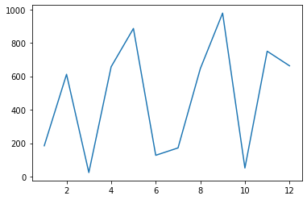

```python
from matplotlib import pyplot as plt
import random

numbers_a = range(1, 13)
numbers_b = [random.randint(1, 1000) for x in range(1, 13)]

plt.plot(numbers_a, numbers_b)
plt.show()
```

## Module Rounding

When we are writing a program that handles money we have to use the Module Decimal because Python's interal floating point arithemtic results as the below:

```python
print(0.10 + 0.35)

from decimal import Decimal

bread = Decimal('0.89')
butter = Decimal('2.99')

Transaction = bread + butter
print(Transaction)
```

```
0.44999999999999996
3.88
```

## Files as Modules

Functions, classes, and files are all limited by **scope**, meaning that they are only visible within the scope in which they were created; as such they are not globally available.

So how do we give files inside the same directory access to each other's variables? In this sense, files are actually modules, so we can import them using the syntax:

```python
##Library directory:
def always_three():
    return 3

##Live script:
#from Library import always_three
```

## Files: Open, Line Iteration, Single Line

To open files in Python we use the with open() and .read() syntax, which opens the document as a single string.  
.readlines allows us to read the text line by line rather than as a whole string  
.readline allows us to read the text a single line at a time, note that if we call the function multiple times it will return an empty string because when the first line is read it is removed from the .readline queue, and without a function to inject the next line it will return empty

```python
with open('document.txt') as doc:
    document_contents = doc.read()
print(document_contents)
```

```
xxxxx
yyyyy
zzzzz
```

```python
with open('document.txt') as doc:
    for line in doc.readlines():
        print(line)
```

```
xxxxx

yyyyy

zzzzz
```

```python
with open('document.txt') as doc:
    document_contents = doc.readline()
print(document_contents)
```

```
xxxxx
```

## Files: Writing and Appending

Similar to opening a file, writing and appending use the same syntax. Note that when we write to a pre-existing file using 'w' and not 'a' we will overwrite the entire file:

```python
with open('document2.txt', 'w') as doc:
    doc.write('File Test')

with open('document2.txt', 'a') as doc2:
    doc2.write(' Appendium')
```

## Files: Open CSV

Opening a CSV is very similar opening a normal file apart from needing to import the csv module. Here we append only the emails into an empty list:

```python
import csv
list_of_emails = []
with open('demobook.csv', newline = '') as users_csv:
    user_reader = csv.DictReader(users_csv)
    for row in user_reader:
        list_of_emails.append(row['email'])

print(list_of_emails)
```

```
['jane@outlook.com', 'pete@outlook.com', 'bob@outlook.com']
```

## Files: Writing CSV

Sometimes we want to programmatically create CSV files that save output so that someone can load it into spreadsheet software, let's say we have a list of users in the system and we want them in CSV for analysis:

```python
lst = [{'Name': 'Fredick Stahn', 'UserID': 4578, 'Admin': False}]

import csv
with open('output.csv', 'w') as output_csv:
    fields = ['Name', 'UserID', 'Admin']
    output_writer = csv.DictWriter(output_csv, fieldnames = fields)
    output_writer.writeheader()
    for item in lst:
        output_writer.writerow(item)
```

Here we imported the csv library and created a new csv file in write mode  
Then we created a fields variable that stores our csv headers  
Then we created a output_writer variable that stores the results of writing our fields to the file  
Using that same output_writer then insert the headers based on the fields  
Finally we iterate through the initial list and write all the rows in the file to the csv

## Reading JSON

JSON is very familiar to the Python syntax for Dictionaries and as such are easy to work with:

```python
import json
with open('output.json') as user_json:
    user_data = json.load(user_json)
print(user_data['chocolate'])
```

```
Semi-sweet Dark
```

## Writing to JSON

Similar to writing to CSVs, we just import the json library and follow the same method:

```python
turn_to_json = {
  'eventId': 674189,
  'dateTime': '2015-02-12T09:23:17.511Z',
  'chocolate': 'Semi-sweet Dark',
  'isTomatoAFruit': True }

import json
with open('output.json', 'w') as json_file:
    json.dump(turn_to_json, json_file)
```